# exercise-12

Keerthana Stanley

Preliminaries:

loading in the data

```r
library(tidyverse)

f <- "https://raw.githubusercontent.com/difiore/ada-2024-datasets/main/Mammal_lifehistories_v2.txt"

d <- read_tsv(f, col_names=TRUE)
```

exploratory data analysis using {skimr}

```r
library(skimr)

d_sumstats <- skim(d)
```

QUESTION: Which of the variables are categorical and which are numeric?

ANSWER: - categorical: order, Family, Genus, species - numerical: mass, gestation, newborn, weaning, wean mass, AFR, max.life, litter size, litters/year, refs

STEP 1: Replace all values of -999 (the authors’ code for missing data) with NA.

documentation for using the {naniar} for this : https://www.rdocumentation.org/packages/naniar/versions/1.1.0/topics/replace_with_na_all

```r
library(naniar)

# replace_with_na_all(dataset, condition)
d <- replace_with_na_all(d, condition = ~.x == -999)
```

STEP 2 Drop the variables litter size and refs.

```r
d <- d %>%
  # using select() to pull out specific columns
  # but in this case I'm using the '-' to exclude litter size and refs
  select(-c(`litter size`, `refs`))
```

STEP 3: Log transform all of the other numeric variables.

mutate(across(where(), .funs)) allows me to apply one function to multiple columns: https://dplyr.tidyverse.org/reference/across.html

my code is based more off of code here: https://www.tidyverse.org/blog/2020/04/dplyr-1-0-0-colwise/

so I wanted to mutate WHERE the variable is numeric and add a log function

```r
# using pipe operator for this
d_log <- d %>%
  # where-- is.numeric; function-- log
  mutate(across(where(is.numeric), log))
```

now gestation(mo), weaning(mo), AFR(mo), max. life(mo), newborn(g), wean mass, and (overall body) mass are all actually the log versions of their original value

STEP 4

Regress the (now log transformed) age [gestation(mo), weaning(mo), AFR(mo) (age at first reproduction), and max. life(mo) (maximum lifespan)] and mass [newborn(g) and wean mass(g)] variables on (now log transformed) overall body mass(g)

Add the residuals to the dataframe as new variables (relGest, relWean, relAFR, relLife, relNewbornMass, and relWeaningMass).

**** Use “na.action=na.exclude” in your lm() calls!!! With this argument set, the residuals will be padded to the correct length by inserting NAs for cases with missing data.

once again using mutate() for these changes/additions in the dataset

each variable listed above is regressed to mass(g) first just printing out the summary for each regression model:

```r
m_gestation <- lm(`gestation(mo)` ~ `mass(g)`, data = d_log, na.action = na.exclude)
summary(m_gestation)
```

```
##
## Call:
## lm(formula = `gestation(mo)` ~ `mass(g)`, data = d_log, na.action = na.exclude)
##
## Residuals:
##      Min       1Q   Median       3Q      Max
## -1.39347 -0.33659 -0.01871  0.32841  1.56568
##
## Coefficients:
##              Estimate Std. Error t value Pr(>|t|)
## (Intercept) -0.939838   0.037045  -25.37   <2e-16 ***
## `mass(g)`    0.249980   0.004561   54.80   <2e-16 ***
## ---
## Signif. codes:  0 '***' 0.001 '**' 0.01 '*' 0.05 '.' 0.1 ' ' 1
##
## Residual standard error: 0.4789 on 989 degrees of freedom
##   (449 observations deleted due to missingness)
## Multiple R-squared:  0.7523, Adjusted R-squared:  0.752
## F-statistic:  3004 on 1 and 989 DF,  p-value: < 2.2e-16
```

```r
m_weaning <- lm(`weaning(mo)` ~ `mass(g)`, data = d_log, na.action = na.exclude)
summary(m_weaning)
```

```
##
## Call:
## lm(formula = `weaning(mo)` ~ `mass(g)`, data = d_log, na.action = na.exclude)
##
## Residuals:
##      Min       1Q   Median       3Q      Max
## -3.10539 -0.38046 -0.05381  0.32894  2.30211
##
## Coefficients:
##              Estimate Std. Error t value Pr(>|t|)
## (Intercept) -0.870379   0.059633  -14.60   <2e-16 ***
## `mass(g)`    0.226004   0.007438   30.39   <2e-16 ***
## ---
## Signif. codes:  0 '***' 0.001 '**' 0.01 '*' 0.05 '.' 0.1 ' ' 1
##
## Residual standard error: 0.7097 on 800 degrees of freedom
##   (638 observations deleted due to missingness)
## Multiple R-squared:  0.5358, Adjusted R-squared:  0.5352
## F-statistic: 923.3 on 1 and 800 DF,  p-value: < 2.2e-16
```

```r
m_AFR <- lm(`AFR(mo)` ~ `mass(g)`, data = d_log, na.action = na.exclude)
summary(m_AFR)
```

```
##
## Call:
## lm(formula = `AFR(mo)` ~ `mass(g)`, data = d_log, na.action = na.exclude)
##
## Residuals:
##      Min       1Q   Median       3Q      Max
## -2.09019 -0.55017 -0.08892  0.59805  1.88853
##
## Coefficients:
##             Estimate Std. Error t value Pr(>|t|)
## (Intercept) 0.393101   0.065898   5.965 3.64e-09 ***
## `mass(g)`   0.276257   0.007984  34.601  < 2e-16 ***
## ---
## Signif. codes:  0 '***' 0.001 '**' 0.01 '*' 0.05 '.' 0.1 ' ' 1
##
## Residual standard error: 0.7668 on 815 degrees of freedom
##   (623 observations deleted due to missingness)
## Multiple R-squared:  0.595,  Adjusted R-squared:  0.5945
## F-statistic:  1197 on 1 and 815 DF,  p-value: < 2.2e-16
```

```r
m_max_life <- lm(`max. life(mo)` ~ `mass(g)`, data = d_log, na.action = na.exclude)
summary(m_max_life)
```

```
##
## Call:
## lm(formula = `max. life(mo)` ~ `mass(g)`, data = d_log, na.action = na.exclude)
##
## Residuals:
##     Min      1Q  Median      3Q     Max
## -1.4969 -0.3053 -0.0303  0.3465  1.4944
##
## Coefficients:
##             Estimate Std. Error t value Pr(>|t|)
## (Intercept) 3.277746   0.053566   61.19   <2e-16 ***
## `mass(g)`   0.218721   0.006063   36.08   <2e-16 ***
## ---
## Signif. codes:  0 '***' 0.001 '**' 0.01 '*' 0.05 '.' 0.1 ' ' 1
##
## Residual standard error: 0.5135 on 590 degrees of freedom
##   (848 observations deleted due to missingness)
## Multiple R-squared:  0.6881, Adjusted R-squared:  0.6875
## F-statistic:  1301 on 1 and 590 DF,  p-value: < 2.2e-16
```

```r
m_newborn <- lm(`newborn(g)` ~ `mass(g)`, data = d_log, na.action = na.exclude)
summary(m_newborn)
```

```
##
## Call:
## lm(formula = `newborn(g)` ~ `mass(g)`, data = d_log, na.action = na.exclude)
##
## Residuals:
##     Min      1Q  Median      3Q     Max
## -3.7195 -0.4223  0.0945  0.4994  2.1097
##
## Coefficients:
##              Estimate Std. Error t value Pr(>|t|)
## (Intercept) -2.623637   0.062441  -42.02   <2e-16 ***
## `mass(g)`    0.949620   0.007812  121.57   <2e-16 ***
## ---
## Signif. codes:  0 '***' 0.001 '**' 0.01 '*' 0.05 '.' 0.1 ' ' 1
##
## Residual standard error: 0.7266 on 814 degrees of freedom
##   (624 observations deleted due to missingness)
## Multiple R-squared:  0.9478, Adjusted R-squared:  0.9477
## F-statistic: 1.478e+04 on 1 and 814 DF,  p-value: < 2.2e-16
```

```r
m_wean_mass <- lm(`wean mass(g)` ~ `mass(g)`, data = d_log, na.action = na.exclude)
summary(m_wean_mass)
```

```
##
## Call:
## lm(formula = `wean mass(g)` ~ `mass(g)`, data = d_log, na.action = na.exclude)
##
## Residuals:
##      Min       1Q   Median       3Q      Max
## -1.94111 -0.30781  0.01617  0.34331  1.29245
##
## Coefficients:
##              Estimate Std. Error t value Pr(>|t|)
## (Intercept) -0.722663   0.061049  -11.84   <2e-16 ***
## `mass(g)`    0.931989   0.008234  113.19   <2e-16 ***
## ---
## Signif. codes:  0 '***' 0.001 '**' 0.01 '*' 0.05 '.' 0.1 ' ' 1
##
## Residual standard error: 0.5191 on 394 degrees of freedom
##   (1044 observations deleted due to missingness)
## Multiple R-squared:  0.9702, Adjusted R-squared:  0.9701
## F-statistic: 1.281e+04 on 1 and 394 DF,  p-value: < 2.2e-16
```

```r
d_new <- d_log %>%
  mutate(
    # gestation
    relGest = resid(lm(`gestation(mo)` ~ `mass(g)`, data = ., na.action = na.exclude)),
    # weaning
    relWean = resid(lm(`weaning(mo)` ~ `mass(g)`, data = ., na.action = na.exclude)),
    # AFR
    relAFR = resid(lm(`AFR(mo)` ~ `mass(g)`, data = ., na.action = na.exclude)),
    # max life
    relLife = resid(lm(`max. life(mo)` ~ `mass(g)`, data = ., na.action = na.exclude)),
    # newborn
    relNewbornMass = resid(lm(`newborn(g)` ~ `mass(g)`, data = ., na.action = na.exclude)),
    # wean mass
    relWeaningMass = resid(lm(`wean mass(g)` ~ `mass(g)`, data = ., na.action = na.exclude))
  )
```

STEP 5: - Plot residuals of max lifespan (relLife) in relation to Order.

Q: Which mammalian orders have the highest residual lifespan? A: primates

- Plot residuals of newborn mass (relNewbornMass) in relation to Order.

Q: Which mammalian orders have the have highest residual newborn mass? A: macroscelidia

- Plot residuals of weaning mass (relWeaningMass) in relation to Order.

Q: Which mammalian orders have the have highest relative weaning mass? A: perissodactyla

using ggplot2 for the plotting

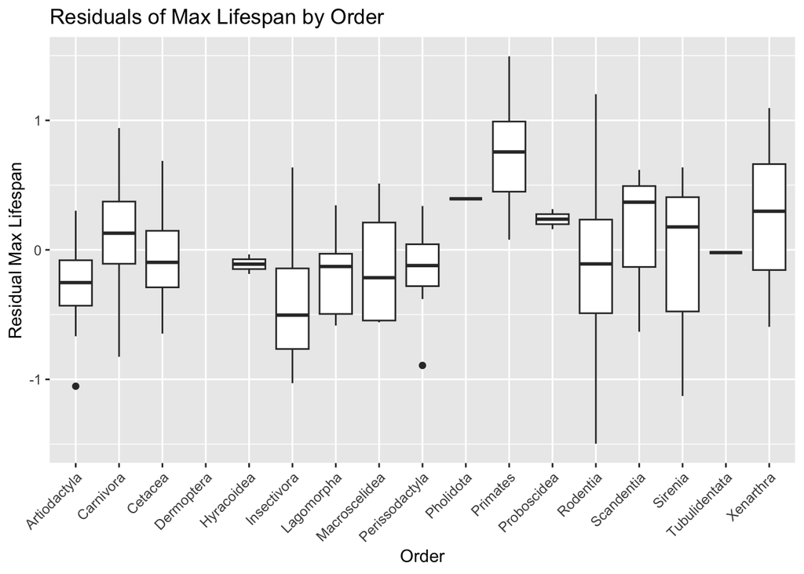

```r
library(ggplot2)

(p1_relLife <- ggplot(d_new, aes(x = order, y = relLife)) +
  geom_boxplot() +
  theme(axis.text.x = element_text(angle = 45, hjust = 1)) +
  labs(title = "Residuals of Max Lifespan by Order",
       x = "Order",
       y = "Residual Max Lifespan"))
```

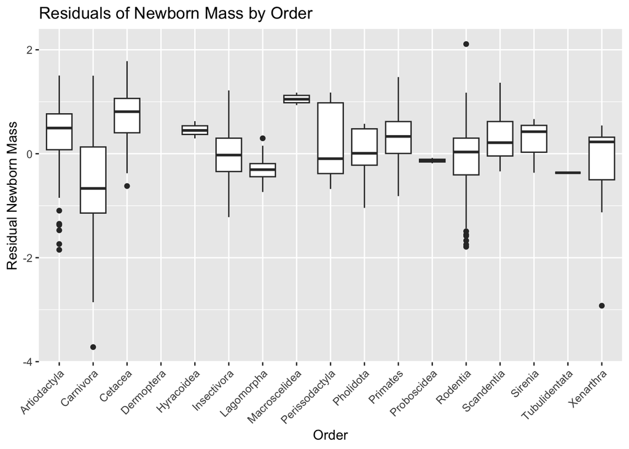

```r
(p2_relNewbornMass <- ggplot(d_new, aes(x = order, y = relNewbornMass)) +
  geom_boxplot() +
  theme(axis.text.x = element_text(angle = 45, hjust = 1)) +
  labs(title = "Residuals of Newborn Mass by Order",
       x = "Order",
       y = "Residual Newborn Mass"))
```

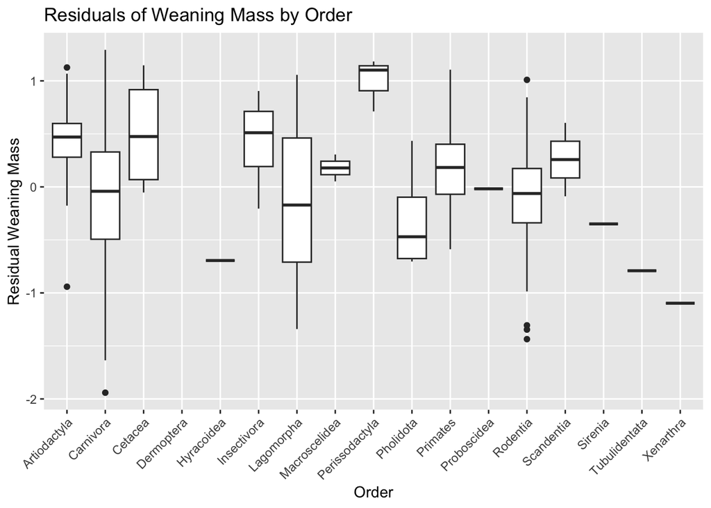

```r
(p3_relWeaningMass <- ggplot(d_new, aes(x = order, y = relWeaningMass)) +
  geom_boxplot() +
  theme(axis.text.x = element_text(angle = 45, hjust = 1)) +
  labs(title = "Residuals of Weaning Mass by Order",
       x = "Order",
       y = "Residual Weaning Mass"))
```

STEP 6:

Run models and a model selection process to evaluate what (now log transformed) variables best predict each of the two response variables, max. life(mo) and AFR(mo), from the set of the following predictors: gestation(mo), newborn(g), weaning(mo), wean mass(g), litters/year, and overall body mass(g).

Calculate and plot the model-averaged coefficients and their CIs across this set of top models.

***HINT: Before running models, winnow your dataset to drop rows that are missing the respective response variable or any of the predictors, e.g., by using drop_na()!!!

QUESTIONS: - For each of the two response variables, indicate what is the best model overall based on AICc and how many models have a delta AICc of 4 or less? *** look for lowest AICc and delta scores

- What variables, if any, appear in all of this set of “top” models? *** can see these scored based on significance, and in how the top models numbered/named with respect to the variables/components that contribute

ANSWERS: - for Max Life: there are 2 models with delta < 4 (and the best model is 1235); for AFR:there are 7 models with delta < 4 (and the best model is 1236)

- for Max Life: gestation, litters/year, and weaning appear in all of the top models; for AFR: gestation and litters/year appear in all of the top models

code based on Module 22 use of the {MuMIn} package

model selection for Max Life

```r
library(MuMIn)

# winnow dataset to drop any missing rows from
d_new <- d_new %>%
  drop_na(`max. life(mo)`, `AFR(mo)`, `gestation(mo)`, `newborn(g)`, `weaning(mo)`, `wean mass(g)`, `litters/year`, `mass(g)`)


# define global model for max. life
# default na.omit should be changed to na. fail to prevent dredge() from trying to fit submodels
m_max_life <- lm(`max. life(mo)` ~ `gestation(mo)` + `newborn(g)` + `weaning(mo)` + `wean mass(g)` + `litters/year` + `mass(g)`, data = d_new, na.action = "na.fail")

# model selection for max. life
# using dredge() from Module 22
mods_max_life <- dredge(m_max_life, beta = "none", m.lim = c(0, 4))
```

```
## Fixed term is "(Intercept)"
```

```r
(mods.list <- get.models(mods_max_life, subset = TRUE))
```

```
## $`40`
##
## Call:
## lm(formula = `max. life(mo)` ~ `gestation(mo)` + `litters/year` +
##     `mass(g)` + `weaning(mo)` + 1, data = d_new, na.action = "na.fail")
##
## Coefficients:
##     (Intercept)  `gestation(mo)`   `litters/year`        `mass(g)`
##         4.03241          0.29528         -0.25252          0.08226
##   `weaning(mo)`
##         0.14159
##
##
## $`52`
##
## Call:
## lm(formula = `max. life(mo)` ~ `gestation(mo)` + `litters/year` +
##     `wean mass(g)` + `weaning(mo)` + 1, data = d_new, na.action = "na.fail")
##
## Coefficients:
##     (Intercept)  `gestation(mo)`   `litters/year`   `wean mass(g)`
##         4.13286          0.28473         -0.26917          0.08586
##   `weaning(mo)`
##         0.13506
##
##
## $`16`
##
## Call:
## lm(formula = `max. life(mo)` ~ `gestation(mo)` + `litters/year` +
##     `mass(g)` + `newborn(g)` + 1, data = d_new, na.action = "na.fail")
##
## Coefficients:
##     (Intercept)  `gestation(mo)`   `litters/year`        `mass(g)`
##         3.98315          0.47997         -0.32926          0.13269
##    `newborn(g)`
##        -0.08198
##
##
## $`8`
```

[output cut: 600 more lines]

[output not shown]

```r
# define global model for max. life
# default na.omit should be changed to na. fail to prevent dredge() from trying to fit submodels
m_AFR <- lm(`AFR(mo)` ~ `gestation(mo)` + `newborn(g)` + `weaning(mo)` + `wean mass(g)` + `litters/year` + `mass(g)`, data = d_new, na.action = "na.fail")

# model selection for max. life
# using dredge() from Module 22
mods_AFR <- dredge(m_AFR, beta = "none", m.lim = c(0, 4))
```

```
## Fixed term is "(Intercept)"
```

```r
(mods.list <- get.models(mods_AFR, subset = TRUE))
```

```
## $`40`
##
## Call:
## lm(formula = `AFR(mo)` ~ `gestation(mo)` + `litters/year` + `mass(g)` +
##     `weaning(mo)` + 1, data = d_new, na.action = "na.fail")
##
## Coefficients:
##     (Intercept)  `gestation(mo)`   `litters/year`        `mass(g)`
##         1.97319          0.40296         -0.70968          0.03619
##   `weaning(mo)`
##         0.14467
##
##
## $`52`
##
## Call:
## lm(formula = `AFR(mo)` ~ `gestation(mo)` + `litters/year` + `wean mass(g)` +
##     `weaning(mo)` + 1, data = d_new, na.action = "na.fail")
##
## Coefficients:
##     (Intercept)  `gestation(mo)`   `litters/year`   `wean mass(g)`
##         2.01331          0.39590         -0.71604          0.03867
##   `weaning(mo)`
##         0.14219
##
##
## $`36`
##
## Call:
## lm(formula = `AFR(mo)` ~ `gestation(mo)` + `litters/year` + `weaning(mo)` +
##     1, data = d_new, na.action = "na.fail")
##
## Coefficients:
##     (Intercept)  `gestation(mo)`   `litters/year`    `weaning(mo)`
##          2.1886           0.5002          -0.7576           0.1253
##
##
## $`44`
##
## Call:
```

[output cut: 595 more lines]

[output not shown]

looking for models with Delta AICc < 4

max life

```r
(mods.avg_max_life <- summary(model.avg(mods_max_life, subset = delta < 4, fit = TRUE)))
```

```
##
## Call:
## model.avg(object = get.models(object = mods_max_life, subset = delta <
##     4))
##
## Component model call:
## lm(formula = `max. life(mo)` ~ <2 unique rhs>, data = d_new, na.action
##      = na.fail)
##
## Component models:
##      df  logLik   AICc delta weight
## 1235  6 -122.21 256.83  0.00   0.81
## 1245  6 -123.63 259.69  2.85   0.19
##
## Term codes:
## `gestation(mo)`  `litters/year`       `mass(g)`  `wean mass(g)`   `weaning(mo)`
##               1               2               3               4               5
##
## Model-averaged coefficients:
## (full average)
##                 Estimate Std. Error Adjusted SE z value Pr(>|z|)
## (Intercept)      4.05185    0.13639     0.13715  29.544  < 2e-16 ***
## `gestation(mo)`  0.29324    0.07370     0.07415   3.955 7.66e-05 ***
## `litters/year`  -0.25574    0.07750     0.07797   3.280  0.00104 **
## `mass(g)`        0.06634    0.03669     0.03674   1.806  0.07094 .
## `weaning(mo)`    0.14033    0.05218     0.05249   2.673  0.00751 **
## `wean mass(g)`   0.01661    0.03522     0.03524   0.471  0.63732
##
## (conditional average)
##                 Estimate Std. Error Adjusted SE z value Pr(>|z|)
## (Intercept)      4.05185    0.13639     0.13715  29.544  < 2e-16 ***
## `gestation(mo)`  0.29324    0.07370     0.07415   3.955 7.66e-05 ***
## `litters/year`  -0.25574    0.07750     0.07797   3.280  0.00104 **
## `mass(g)`        0.08226    0.01897     0.01908   4.311 1.62e-05 ***
## `weaning(mo)`    0.14033    0.05218     0.05249   2.673  0.00751 **
## `wean mass(g)`   0.08586    0.02161     0.02174   3.949 7.83e-05 ***
## ---
## Signif. codes:  0 '***' 0.001 '**' 0.01 '*' 0.05 '.' 0.1 ' ' 1
```

max life- CI (as shown in Module 22)

```r
confint(mods.avg_max_life)
```

```
##                       2.5 %     97.5 %
## (Intercept)      3.78304344  4.3206545
## `gestation(mo)`  0.14790552  0.4385654
## `litters/year`  -0.40855582 -0.1029259
## `mass(g)`        0.04486373  0.1196587
## `weaning(mo)`    0.03744025  0.2432151
## `wean mass(g)`   0.04324855  0.1284642
```

plotting for max life model-averaged coeff

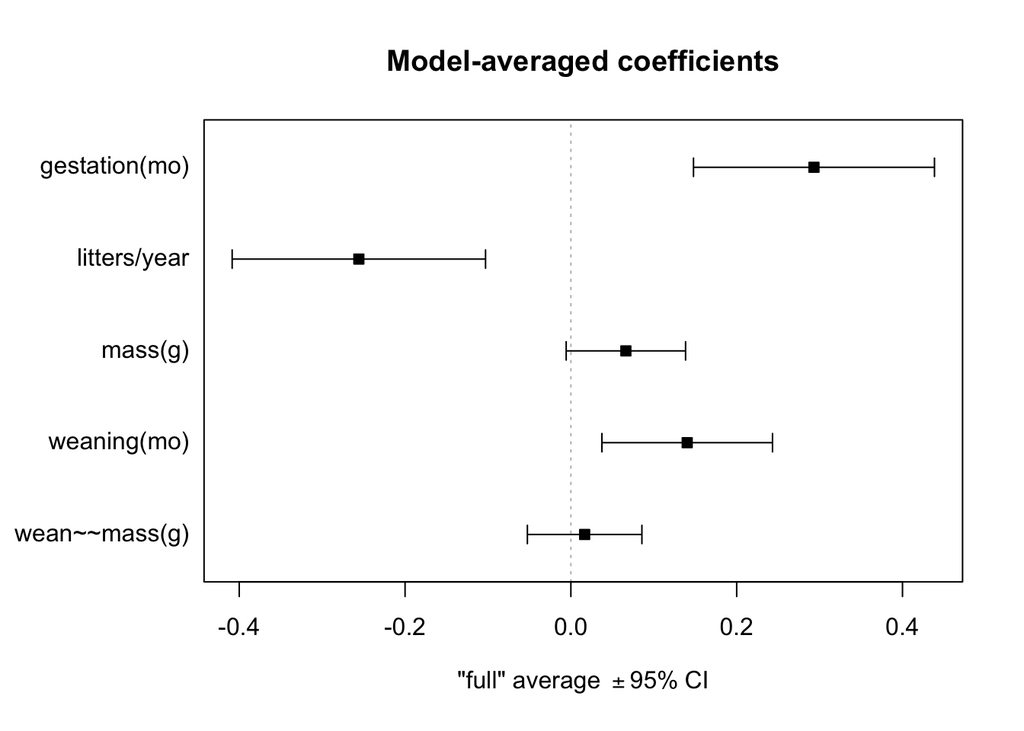

```r
plot(mods.avg_max_life, full = TRUE, intercept = FALSE)
```

AFR

```r
(mods.avg_AFR <- summary(model.avg(mods_AFR, subset = delta < 4, fit = TRUE)))
```

```
##
## Call:
## model.avg(object = get.models(object = mods_AFR, subset = delta <
##     4))
##
## Component model call:
## lm(formula = `AFR(mo)` ~ <7 unique rhs>, data = d_new, na.action =
##      na.fail)
##
## Component models:
##      df  logLik   AICc delta weight
## 1236  6 -154.40 321.23  0.00   0.26
## 1256  6 -154.55 321.52  0.30   0.22
## 126   5 -155.76 321.82  0.59   0.19
## 1246  6 -154.70 321.82  0.59   0.19
## 12    4 -157.96 324.12  2.89   0.06
## 123   5 -157.26 324.81  3.58   0.04
## 125   5 -157.32 324.94  3.71   0.04
##
## Term codes:
## `gestation(mo)`  `litters/year`       `mass(g)`    `newborn(g)`  `wean mass(g)`
##               1               2               3               4               5
##   `weaning(mo)`
##               6
##
## Model-averaged coefficients:
## (full average)
##                  Estimate Std. Error Adjusted SE z value Pr(>|z|)
## (Intercept)      2.077348   0.155135    0.155747  13.338  < 2e-16 ***
## `gestation(mo)`  0.431246   0.102802    0.103227   4.178 2.95e-05 ***
## `litters/year`  -0.742844   0.096772    0.097242   7.639  < 2e-16 ***
## `mass(g)`        0.010362   0.020067    0.020111   0.515    0.606
## `weaning(mo)`    0.120698   0.075321    0.075576   1.597    0.110
## `wean mass(g)`   0.009658   0.020793    0.020841   0.463    0.643
## `newborn(g)`     0.007523   0.019607    0.019651   0.383    0.702
##
## (conditional average)
##                 Estimate Std. Error Adjusted SE z value Pr(>|z|)
## (Intercept)      2.07735    0.15513     0.15575  13.338  < 2e-16 ***
## `gestation(mo)`  0.43125    0.10280     0.10323   4.178 2.95e-05 ***
## `litters/year`  -0.74284    0.09677     0.09724   7.639  < 2e-16 ***
## `mass(g)`        0.03472    0.02244     0.02257   1.538   0.1240
## `weaning(mo)`    0.14080    0.06154     0.06190   2.275   0.0229 *
## `wean mass(g)`   0.03704    0.02538     0.02553   1.451   0.1468
## `newborn(g)`     0.03957    0.02746     0.02763   1.432   0.1520
## ---
## Signif. codes:  0 '***' 0.001 '**' 0.01 '*' 0.05 '.' 0.1 ' ' 1
```

AFR- CI (as shown in Module 22)

```r
confint(mods.avg_AFR)
```

```
##                        2.5 %      97.5 %
## (Intercept)      1.772090289  2.38260614
## `gestation(mo)`  0.228924250  0.63356700
## `litters/year`  -0.933435667 -0.55225257
## `mass(g)`       -0.009518041  0.07895965
## `weaning(mo)`    0.019474192  0.26213558
## `wean mass(g)`  -0.012989579  0.08706876
## `newborn(g)`    -0.014572450  0.09371854
```

plotting for AFR model-averaged coeff

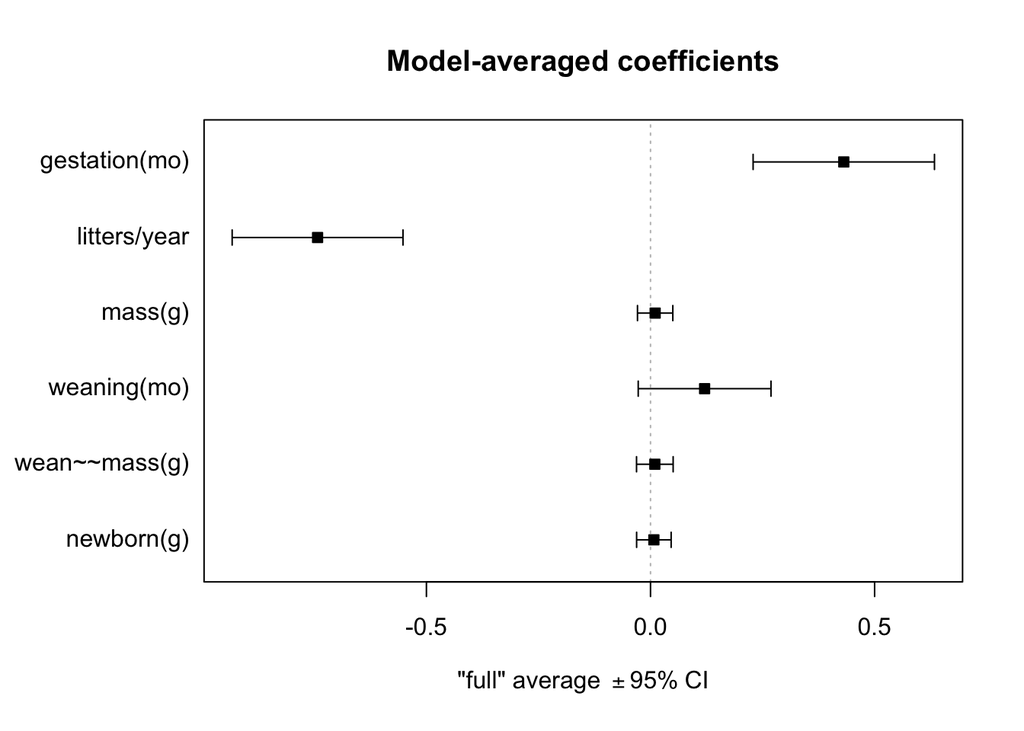

```r
plot(mods.avg_AFR, full = TRUE, intercept = FALSE)
```